# : ¿La diversificación de la oferta alimentaria está asociada con una mayor disponibilidad de nutrientes?

17 de septiembre de 2026

[figure not shown]

# 1 Introducción

Este informe forma parte de un trabajo de **minería de datos** sobre la oferta alimentaria de 10 países de Sudamérica (Argentina, Bolivia, Brasil, Chile, Colombia, Ecuador, Paraguay, Perú, Uruguay y Venezuela). Se trabaja con tres fuentes de datos que representan distintos niveles de agregación del mismo fenómeno:

| Dataset | Granularidad | Filas | Descripción |
| --- | --- | --- | --- |
| `paises_definitivo_kpis` | 1 fila por país | 10 | KPIs agregados (promedio del período) |
| `paises_pca_clusters` | 1 fila por país | 10 | Igual al anterior + componentes principales (`PC1`,`PC2`) y clúster (`Cluster_KMeans`) |
| `panel_pais_anio_definitivo` | 1 fila por país-año | 140 | Panel 2010-2023 con indicadores de comercio exterior y clúster asignado |

Los objetivos del análisis son:

1. Evaluar la **calidad** de los datos (valores faltantes, duplicados, atípicos, consistencia entre datasets).
2. Estudiar la **distribución** de las variables clave (forma, dispersión, normalidad).
3. Analizar la **diversidad** de la oferta alimentaria entre países y en el tiempo.
4. Revisar la reducción de dimensionalidad (**PCA**) y la **segmentación** (clustering) ya calculadas.
5. Explorar la **dinámica temporal** (panel 2010-2023): comercio, autosuficiencia, dependencia.

# 2 Carga de datos

```r
kpis    <- read_csv("paises_definitivo_kpis.csv")    |> clean_names()
pca_cl  <- read_csv("paises_pca_clusters.csv")        |> clean_names()
panel   <- read_csv("panel_pais_anio_definitivo.csv") |> clean_names()

# clean_names() deja columnas como "aceites_vegetales", "almidon_de_raices",
# "cereales_exc_cerveza", "pais", "ano", etc. La columna "Cluster_KMeans"
# puede quedar como "cluster_kmeans" o "cluster_k_means" según la versión
# de janitor instalada -> la normalizamos explícitamente para que el resto
# del script no dependa de adivinar el nombre exacto.
names(pca_cl) <- str_replace(names(pca_cl), "^cluster.*means$", "cluster_kmeans")

glimpse(kpis)
```

```
## Rows: 10
## Columns: 23
## $ pais                          <chr> "Argentina", "Bolivia", "Brasil", "Chile…
## $ aceites_vegetales             <dbl> 16.980, 2.820, 24.888, 7.484, 17.212, 19…
## $ almidon_de_raices             <dbl> 45.418, 97.104, 54.138, 56.804, 82.616, …
## $ carne                         <dbl> 112.918, 80.546, 101.618, 93.204, 61.540…
## $ cereales_exc_cerveza          <dbl> 143.432, 135.514, 126.942, 144.908, 134.…
## $ cultivos_azucareros           <dbl> 0.0000000, 0.0000000, 15.8540000, 0.0000…
## $ frutas_excluso_vino           <dbl> 76.894, 88.508, 102.870, 66.220, 146.220…
## $ grasas_animales               <dbl> 4.958, 3.420, 4.964, 4.422, 1.544, 4.770…
## $ hortalizas                    <dbl> 76.740, 41.680, 51.314, 76.430, 52.148, …
## $ huevos                        <dbl> 17.232, 7.064, 12.808, 9.888, 14.754, 7.…
## $ leche_excl_mantequilla        <dbl> 171.490, 40.454, 156.094, 100.080, 115.7…
## $ legumbres_secas               <dbl> 8.264, 5.790, 12.904, 3.810, 6.582, 2.10…
## $ nueces                        <dbl> 0.840, 6.920, 0.976, 3.134, 0.796, 0.294…
## $ pescado_y_frutos_de_mar       <dbl> 7.064, 2.388, 8.204, 14.520, 9.982, 6.56…
## $ food_diversity_index          <dbl> 1.974522, 1.920967, 2.085022, 2.000567, …
## $ kcal_persona_dia_total        <dbl> 3321.562, 2394.076, 3378.090, 3081.312, …
## $ proteina_g_persona_dia_total  <dbl> 118.920, 80.916, 104.190, 104.184, 82.23…
## $ grasa_g_persona_dia_total     <dbl> 134.192, 58.674, 139.318, 94.826, 102.26…
## $ frutas_hortalizas_g_dia       <dbl> 420.9151, 356.6795, 422.4219, 390.8219, …
## $ score_frutas_verduras         <dbl> 100.0, 89.2, 100.0, 97.7, 100.0, 58.2, 1…
## $ pct_energia_grasa             <dbl> 36.4, 22.1, 37.1, 27.7, 29.6, 35.1, 26.8…
## $ score_grasa                   <dbl> 68.0, 100.0, 64.5, 100.0, 100.0, 74.5, 1…
## $ indice_calidad_oferta_parcial <dbl> 84.0, 94.6, 82.2, 98.8, 100.0, 66.4, 100…
```

> **Nota:** coloca los tres CSV en la misma carpeta que este `.Rmd` (o ajusta la ruta en `read_csv()`). `read_csv()` maneja automáticamente el BOM UTF-8 que traen los archivos originales.

# 3 Resumen visual

*Antes de entrar en el detalle técnico, estos cuatro gráficos resumen los hallazgos principales del estudio.*

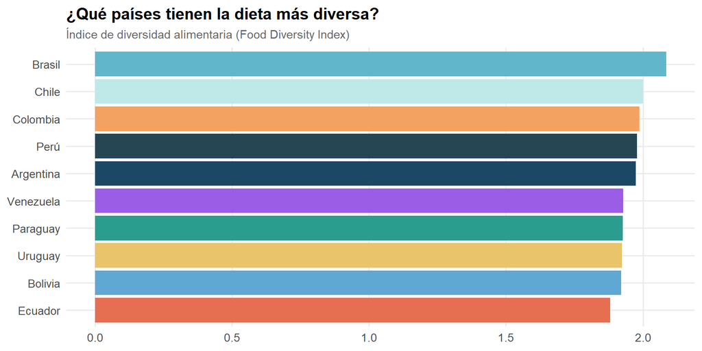

```r
kpis |>
  ggplot(aes(x = fct_reorder(pais, food_diversity_index), y = food_diversity_index,
             fill = pais)) +
  geom_col(show.legend = FALSE) +
  scale_fill_manual(values = paleta_paises) +
  coord_flip() +
  labs(title = "¿Qué países tienen la dieta más diversa?",
       subtitle = "Índice de diversidad alimentaria (Food Diversity Index)",
       x = NULL, y = NULL)
```

📊 **Lectura rápida:** Brasil y Chile encabezan la diversidad alimentaria; Ecuador y Bolivia son los que menos variedad de grupos de alimentos ofrecen.

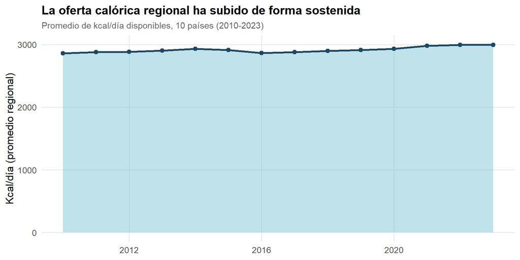

```r
panel |>
  group_by(ano) |>
  summarise(kcal_regional = mean(kcal_dia_total)) |>
  ggplot(aes(x = ano, y = kcal_regional)) +
  geom_area(fill = "#62B6CB", alpha = 0.4) +
  geom_line(color = "#1B4965", linewidth = 1.2) +
  geom_point(color = "#1B4965", size = 2) +
  labs(title = "La oferta calórica regional ha subido de forma sostenida",
       subtitle = "Promedio de kcal/día disponibles, 10 países (2010-2023)",
       x = NULL, y = "Kcal/día (promedio regional)")
```

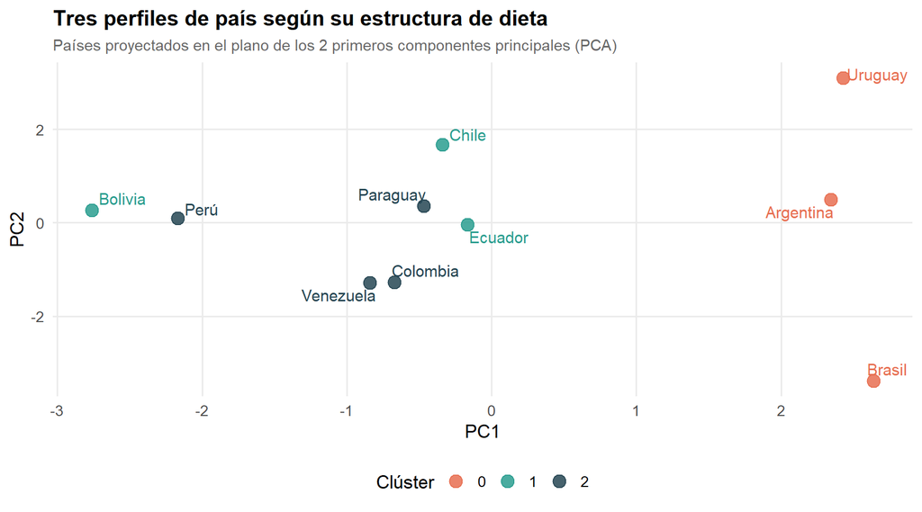

```r
pca_cl |>
  ggplot(aes(x = pc1, y = pc2, color = factor(cluster_kmeans))) +
  geom_point(size = 4, alpha = 0.85) +
  ggrepel::geom_text_repel(aes(label = pais), show.legend = FALSE, size = 4) +
  scale_color_manual(values = c("#E76F51","#2A9D8F","#264653"), name = "Clúster") +
  labs(title = "Tres perfiles de país según su estructura de dieta",
       subtitle = "Países proyectados en el plano de los 2 primeros componentes principales (PCA)",
       x = "PC1", y = "PC2")
```

📊 **Lectura rápida:** los países se agrupan en 3 perfiles: grandes productores/exportadores del Cono Sur (Argentina, Brasil, Uruguay), un grupo intermedio (Bolivia, Chile, Ecuador) y un grupo orientado al consumo interno (Colombia, Paraguay, Perú, Venezuela).

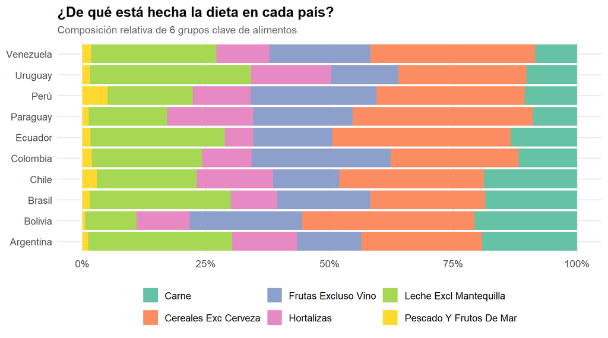

```r
grupos_resumen <- c("carne","cereales_exc_cerveza","hortalizas",
                     "frutas_excluso_vino","leche_excl_mantequilla",
                     "pescado_y_frutos_de_mar")

kpis |>
  select(pais, all_of(grupos_resumen)) |>
  pivot_longer(-pais, names_to = "grupo", values_to = "valor") |>
  mutate(grupo = str_to_title(str_replace_all(grupo, "_", " "))) |>
  ggplot(aes(x = pais, y = valor, fill = grupo)) +
  geom_col(position = "fill") +
  scale_fill_brewer(palette = "Set2", name = NULL) +
  scale_y_continuous(labels = scales::percent) +
  coord_flip() +
  labs(title = "¿De qué está hecha la dieta en cada país?",
       subtitle = "Composición relativa de 6 grupos clave de alimentos",
       x = NULL, y = NULL)
```

📊 **Lectura rápida:** aunque todos los países comparten los mismos grupos de alimentos, el peso relativo de cada uno varía notablemente — por ejemplo, el peso de cereales frente a carne o pescado marca buena parte de la diferencia regional.

# 4 Calidad de los datos

## 4.1 Valores faltantes

```r
list(KPIs = kpis, PCA_Clusters = pca_cl, Panel = panel) |>
  map_dfr(~ tibble(na_total = sum(is.na(.x)),
                    filas = nrow(.x),
                    columnas = ncol(.x)),
          .id = "dataset") |>
  datatable(caption = "Resumen de valores faltantes por dataset")
```

|  | dataset | na_total | filas | columnas |
| --- | --- | --- | --- | --- |
| 1 | KPIs | 0 | 10 | 23 |
| 2 | PCA_Clusters | 0 | 10 | 26 |
| 3 | Panel | 0 | 140 | 31 |

## 4.2 Duplicados y consistencia de claves

```r
# Duplicados exactos
cat("Filas duplicadas - KPIs:", sum(duplicated(kpis)), "\n")
```

```
## Filas duplicadas - KPIs: 0
```

```r
cat("Filas duplicadas - PCA/Clusters:", sum(duplicated(pca_cl)), "\n")
```

```
## Filas duplicadas - PCA/Clusters: 0
```

```r
cat("Filas duplicadas - Panel:", sum(duplicated(panel)), "\n")
```

```
## Filas duplicadas - Panel: 0
```

```r
# Consistencia: ¿el panel tiene exactamente 14 años x 10 países = 140 filas?
panel |> count(pais) |> datatable(caption = "N° de años reportados por país")
```

|  | pais | n |
| --- | --- | --- |
| 1 | Argentina | 14 |
| 2 | Bolivia | 14 |
| 3 | Brasil | 14 |
| 4 | Chile | 14 |
| 5 | Colombia | 14 |
| 6 | Ecuador | 14 |
| 7 | Paraguay | 14 |
| 8 | Perú | 14 |
| 9 | Uruguay | 14 |
| 10 | Venezuela | 14 |

```r
# ¿Los mismos 10 países aparecen en los tres datasets?
setdiff(kpis$pais, panel$pais)
```

```
## character(0)
```

```r
setdiff(panel$pais, kpis$pais)
```

```
## character(0)
```

## 4.3 Valores atípicos (outliers): detección, diagnóstico y tratamiento

### 4.3.1 Paso 1 — Detección ingenua (pooled, sin agrupar por país)

Se identifican primero con el criterio de rango intercuartílico (IQR) sobre el **panel completo mezclado** (140 filas país-año juntas), que es la forma más común -y más ingenua- de detectar outliers.

```r
detectar_outliers <- function(x) {
  q1 <- quantile(x, 0.25, na.rm = TRUE)
  q3 <- quantile(x, 0.75, na.rm = TRUE)
  iqr <- q3 - q1
  sum(x < (q1 - 1.5 * iqr) | x > (q3 + 1.5 * iqr), na.rm = TRUE)
}

n_outliers_pooled <- panel |>
  select(where(is.numeric), -ano, -cluster) |>
  summarise(across(everything(), detectar_outliers)) |>
  pivot_longer(everything(), names_to = "variable", values_to = "n_outliers") |>
  arrange(desc(n_outliers))

n_outliers_pooled |>
  datatable(caption = "N° de outliers por variable - detección pooled (ingenua)")
```

|  | variable | n_outliers |
| --- | --- | --- |
| 1 | exportaciones_total | 28 |
| 2 | nueces | 20 |
| 3 | produccion_total | 18 |
| 4 | score_frutas_verduras | 16 |
| 5 | cultivos_azucareros | 15 |
| 6 | almidon_de_raices | 14 |
| 7 | pescado_y_frutos_de_mar | 14 |
| 8 | suministro_interno_total | 14 |
| 9 | indice_calidad_oferta | 9 |
| 10 | importaciones_total | 8 |

[output cut: 18 more lines]

### 4.3.2 Paso 2 — Diagnóstico: ¿son errores o son estructura real del país?

Antes de “tratar” nada hay que preguntarse **a qué país pertenecen** esos outliers. Si un mismo país concentra casi todos sus años como outlier en una variable, no es un dato mal medido: es que ese país **estructuralmente** tiene un nivel distinto (p. ej. Argentina y Brasil son economías mucho más grandes, por lo que su producción/exportación va a ser siempre “atípica” frente al resto).

```r
diagnostico_outlier <- function(df, col) {
  q1 <- quantile(df[[col]], 0.25, na.rm = TRUE)
  q3 <- quantile(df[[col]], 0.75, na.rm = TRUE)
  iqr <- q3 - q1
  lo <- q1 - 1.5 * iqr; hi <- q3 + 1.5 * iqr
  df |>
    filter(.data[[col]] < lo | .data[[col]] > hi) |>
    count(pais, name = "n_anios_atipicos") |>
    mutate(variable = col)
}

vars_revisar <- c("produccion_total", "exportaciones_total",
                   "food_diversity_index", "almidon_de_raices")

map_dfr(vars_revisar, ~ diagnostico_outlier(panel, .x)) |>
  datatable(caption = "¿Qué países concentran los outliers pooled? (estructura vs. error)")
```

|  | pais | n_anios_atipicos | variable |
| --- | --- | --- | --- |
| 1 | Argentina | 4 | produccion_total |
| 2 | Brasil | 14 | produccion_total |
| 3 | Argentina | 14 | exportaciones_total |
| 4 | Brasil | 14 | exportaciones_total |
| 5 | Brasil | 7 | food_diversity_index |
| 6 | Paraguay | 14 | almidon_de_raices |

Si `n_anios_atipicos` es igual (o casi igual) al número total de años del país (14), **es escala, no error** → no se elimina. Si un país aparece con **1-2 años atípicos** dentro de su propia serie, ahí sí puede ser una anomalía real de comportamiento.

### 4.3.3 Paso 3 — Detección correcta: agrupada por país (within-country)

La forma correcta de detectar anomalías de *comportamiento* (no de escala) es aplicar el IQR **dentro de la serie temporal de cada país por separado**, comparando cada país solo contra sí mismo.

```r
outliers_within <- function(df, col) {
  df |>
    group_by(pais) |>
    mutate(q1 = quantile(.data[[col]], 0.25),
           q3 = quantile(.data[[col]], 0.75),
           iqr = q3 - q1,
           es_outlier = .data[[col]] < (q1 - 1.5*iqr) | .data[[col]] > (q3 + 1.5*iqr)) |>
    ungroup() |>
    filter(es_outlier) |>
    select(pais, ano, all_of(col))
}

outliers_within(panel, "exportaciones_total") |>
  datatable(caption = "Anomalías reales de Exportaciones_total (dentro de la serie de cada país)")
```

|  | pais | ano | exportaciones_total |
| --- | --- | --- | --- |
| 1 | Brasil | 2023 | 86240 |
| 2 | Venezuela | 2021 | 76 |
| 3 | Venezuela | 2022 | 80 |
| 4 | Venezuela | 2023 | 144 |

> **Hallazgo:** con detección pooled, `exportaciones_total` mostraba 28 “outliers” (prácticamente todos los años de Argentina y Brasil). Con detección *within-country*, quedan solo un puñado de años realmente anómalos dentro de la trayectoria propia de cada país — entre ellos, el **colapso de las exportaciones de Venezuela en 2021-2023**, que sí es una anomalía de comportamiento genuina (posiblemente ligada a la crisis económica del país) y merece discutirse en el análisis, no descartarse.

### 4.3.4 Paso 4 — Tratamiento aplicado

No se eliminan ni imputan filas: no hay evidencia de error de captura, y borrar los años “grandes” de Argentina/Brasil sesgaría el estudio quitando justo la variabilidad entre países que la pregunta de investigación busca explicar. En su lugar se aplican tres tratamientos, cada uno para un propósito distinto:

```r
# 1) Transformación logarítmica para variables de volumen muy asimétricas,
#    a usar en correlación/PCA/regresión (reduce la influencia de la escala
#    sin descartar datos)
panel_log <- panel |>
  mutate(across(c(produccion_total, importaciones_total, exportaciones_total,
                   suministro_interno_total),
                ~ log1p(.x), .names = "log_{.col}"))

# 2) Uso de ratios ya normalizados por tamaño de país en vez de totales
#    crudos para comparaciones cruzadas (ya vienen en el dataset)
comparacion_cruzada <- panel |>
  select(pais, ano, ratio_autosuficiencia, ratio_dependencia_importaciones,
         ratio_orientacion_exportadora)

# 3) Estadística robusta (mediana / MAD) para resúmenes descriptivos que no
#    se distorsionen por los países más grandes
panel |>
  group_by(pais) |>
  summarise(mediana_produccion = median(produccion_total),
            mad_produccion = mad(produccion_total)) |>
  arrange(desc(mediana_produccion)) |>
  datatable(caption = "Resumen robusto de producción total por país (mediana/MAD)")
```

|  | pais | mediana_produccion | mad_produccion |
| --- | --- | --- | --- |
| 1 | Brasil | 1009091.5 | 28465.1787 |
| 2 | Argentina | 120986.5 | 17908.3254 |
| 3 | Colombia | 68512.5 | 4311.400799999999 |
| 4 | Perú | 41336.5 | 3523.3989 |
| 5 | Ecuador | 25252 | 768.7280999999999 |
| 6 | Chile | 22621 | 768.7280999999999 |
| 7 | Paraguay | 19808.5 | 2267.6367 |
| 8 | Venezuela | 18303 | 3139.4055 |
| 9 | Bolivia | 16155.5 | 3409.98 |
| 10 | Uruguay | 7863.5 | 264.6441 |

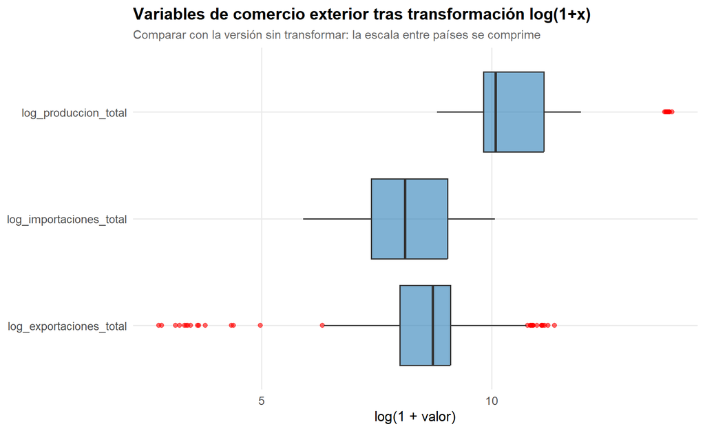

```r
panel_log |>
  select(pais, log_produccion_total, log_importaciones_total, log_exportaciones_total) |>
  pivot_longer(-pais, names_to = "variable", values_to = "valor") |>
  ggplot(aes(x = variable, y = valor)) +
  geom_boxplot(fill = "#2c7fb8", alpha = 0.6, outlier.color = "red") +
  labs(title = "Variables de comercio exterior tras transformación log(1+x)",
       subtitle = "Comparar con la versión sin transformar: la escala entre países se comprime",
       x = NULL, y = "log(1 + valor)") +
  coord_flip()
```

**Resumen del tratamiento (documentar así en el informe):**

| Tipo de outlier detectado | Ejemplo | Tratamiento |
| --- | --- | --- |
| Escala/estructura entre países | Producción y exportación de Argentina/Brasil | No se elimina. Se usa `log1p()` para modelado y ratios normalizados para comparación cruzada |
| Comportamiento real dentro de un país | Caída de exportaciones de Venezuela 2021-2023 | Se conserva y se documenta como hallazgo, no como error |
| Sin evidencia de error de captura | — | No se imputa ni se borra ninguna fila del dataset |

# 5 Análisis de distribución

## 5.1 Resumen estadístico general

```r
kpis |> select(-pais) |> skim()
```

Data summary

| Name | select(kpis, -pais) |
| --- | --- |
| Number of rows | 10 |
| Number of columns | 22 |
| _______________________ |  |
| Column type frequency: |  |
| numeric | 22 |
| ________________________ |  |
| Group variables | None |

**Variable type: numeric**

| skim_variable | n_missing | complete_rate | mean | sd | p0 | p25 | p50 | p75 | p100 | hist |
| --- | --- | --- | --- | --- | --- | --- | --- | --- | --- | --- |
| aceites_vegetales | 0 | 1 | 14.77 | 6.55 | 2.82 | 10.43 | 16.46 | 18.56 | 24.89 | ▂▃▃▇▂ |
| almidon_de_raices | 0 | 1 | 76.28 | 49.71 | 23.34 | 47.60 | 56.58 | 93.48 | 184.20 | ▇▆▂▂▂ |
| carne | 0 | 1 | 69.89 | 26.40 | 36.67 | 53.42 | 64.39 | 90.04 | 112.92 | ▅▇▅▂▅ |
| cereales_exc_cerveza | 0 | 1 | 144.78 | 11.87 | 126.94 | 137.04 | 144.17 | 148.73 | 169.57 | ▅▇▇▂▂ |
| cultivos_azucareros | 0 | 1 | 1.81 | 4.94 | 0.00 | 0.00 | 0.08 | 0.68 | 15.85 | ▇▁▁▁▁ |
| frutas_excluso_vino | 0 | 1 | 93.70 | 26.90 | 62.53 | 78.32 | 88.76 | 99.67 | 146.22 | ▆▇▂▁▃ |
| grasas_animales | 0 | 1 | 3.68 | 1.85 | 0.85 | 2.01 | 4.30 | 4.91 | 6.37 | ▅▁▂▇▂ |
| hortalizas | 0 | 1 | 60.66 | 23.31 | 22.49 | 48.33 | 56.43 | 75.07 | 106.73 | ▂▇▃▃▂ |
| huevos | 0 | 1 | 11.86 | 4.04 | 6.36 | 8.36 | 11.96 | 14.63 | 17.23 | ▇▂▅▅▅ |
| leche_excl_mantequilla | 0 | 1 | 116.94 | 51.04 | 40.45 | 91.97 | 109.10 | 146.01 | 212.94 | ▅▇▅▅▂ |
| legumbres_secas | 0 | 1 | 7.06 | 3.44 | 2.10 | 4.30 | 7.42 | 9.09 | 12.90 | ▇▂▅▇▂ |
| nueces | 0 | 1 | 1.46 | 2.11 | 0.05 | 0.32 | 0.82 | 1.07 | 6.92 | ▇▁▁▁▁ |
| pescado_y_frutos_de_mar | 0 | 1 | 9.92 | 6.68 | 2.39 | 6.69 | 8.15 | 10.33 | 26.59 | ▇▇▂▁▂ |
| food_diversity_index | 0 | 1 | 1.96 | 0.06 | 1.88 | 1.92 | 1.95 | 1.98 | 2.09 | ▃▆▇▁▂ |
| kcal_persona_dia_total | 0 | 1 | 2962.36 | 358.58 | 2394.08 | 2634.67 | 3085.64 | 3260.80 | 3378.09 | ▇▁▂▇▇ |
| proteina_g_persona_dia_total | 0 | 1 | 89.07 | 17.58 | 66.91 | 75.06 | 85.86 | 103.62 | 118.92 | ▇▅▂▇▂ |
| grasa_g_persona_dia_total | 0 | 1 | 99.86 | 26.11 | 58.67 | 89.40 | 97.43 | 116.31 | 139.32 | ▃▂▇▂▃ |
| frutas_hortalizas_g_dia | 0 | 1 | 422.90 | 95.54 | 232.94 | 380.03 | 420.83 | 501.79 | 543.47 | ▂▂▅▇▇ |
| score_frutas_verduras | 0 | 1 | 93.92 | 13.06 | 58.20 | 95.00 | 100.00 | 100.00 | 100.00 | ▁▁▁▁▇ |
| pct_energia_grasa | 0 | 1 | 30.06 | 5.58 | 21.40 | 27.03 | 30.55 | 34.55 | 37.10 | ▅▂▅▅▇ |
| score_grasa | 0 | 1 | 88.50 | 14.45 | 64.50 | 77.25 | 96.25 | 100.00 | 100.00 | ▃▂▂▂▇ |
| indice_calidad_oferta_parcial | 0 | 1 | 91.21 | 10.83 | 66.40 | 86.20 | 93.95 | 99.70 | 100.00 | ▁▁▂▁▇ |

## 5.2 Forma de la distribución (asimetría y curtosis)

```r
kpis |>
  select(where(is.numeric)) |>
  summarise(across(everything(),
                    list(media = ~mean(.x), sd = ~sd(.x),
                         asimetria = ~skewness(.x), curtosis = ~kurtosis(.x)))) |>
  pivot_longer(everything(), names_to = "campo", values_to = "valor") |>
  separate(campo, into = c("variable", "medida"), sep = "_(?=[^_]+$)") |>
  pivot_wider(names_from = medida, values_from = valor) |>
  datatable(caption = "Medidas de forma por variable (dataset KPIs, n=10 países)") |>
  formatRound(columns = c("media","sd","asimetria","curtosis"), digits = 2)
```

|  | variable | media | sd | asimetria | curtosis |
| --- | --- | --- | --- | --- | --- |
| 1 | aceites_vegetales | 14.7738 | 6.545159327489456 | -0.4348362696757033 | 2.406546875833087 |
| 2 | almidon_de_raices | 76.2778 | 49.7114687813587 | 1.087187698893903 | 3.208100685262427 |
| 3 | carne | 69.8876 | 26.3961982919258 | 0.2887065673945569 | 1.840509208512092 |
| 4 | cereales_exc_cerveza | 144.783 | 11.87351032059742 | 0.6225617638314852 | 3.164447623865894 |
| 5 | cultivos_azucareros | 1.812466666666667 | 4.944611383448989 | 2.644868126748056 | 8.04235764433491 |
| 6 | frutas_excluso_vino | 93.7004 | 26.89658191914603 | 0.8713086233620363 | 2.688724951443926 |
| 7 | grasas_animales | 3.6762 | 1.853771998445932 | -0.3746259662393582 | 1.856150777852809 |
| 8 | hortalizas | 60.6564 | 23.30967453512239 | 0.3768876512292998 | 2.902144762912809 |
| 9 | huevos | 11.857 | 4.035222395082801 | 0.001853466179826897 | 1.623903629330674 |
| 10 | leche_excl_mantequilla | 116.9408 | 51.0418666952271 | 0.4343052873228965 | 2.515012589590325 |

[output cut: 12 more lines]

## 5.3 Histogramas de variables clave

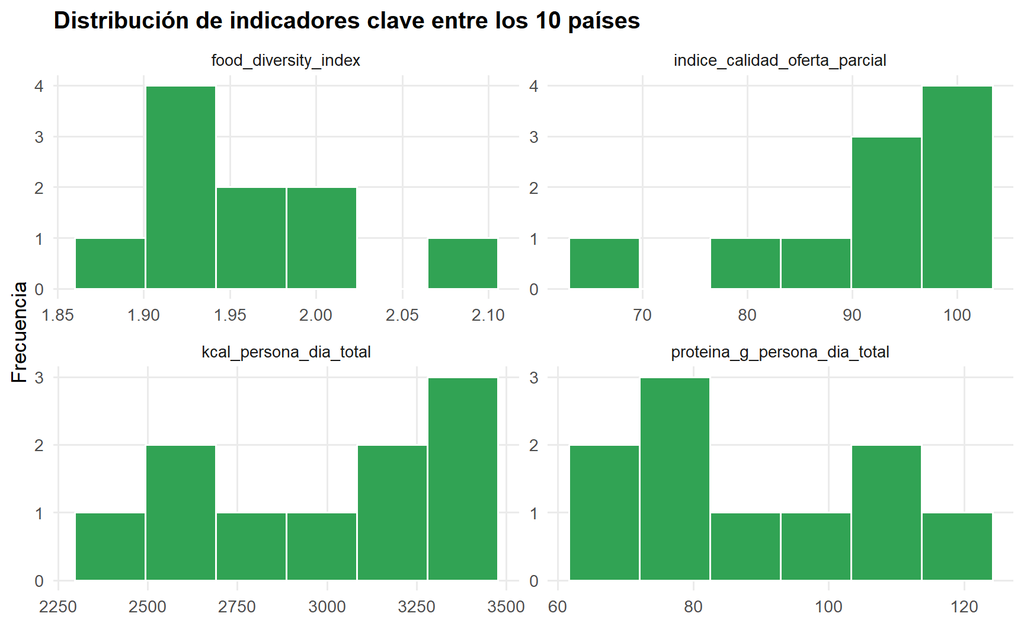

```r
vars_clave <- c("food_diversity_index", "kcal_persona_dia_total",
                 "proteina_g_persona_dia_total", "indice_calidad_oferta_parcial")

kpis |>
  select(pais, all_of(vars_clave)) |>
  pivot_longer(-pais, names_to = "variable", values_to = "valor") |>
  ggplot(aes(x = valor)) +
  geom_histogram(bins = 6, fill = "#31a354", color = "white") +
  facet_wrap(~variable, scales = "free") +
  labs(title = "Distribución de indicadores clave entre los 10 países",
       x = NULL, y = "Frecuencia")
```

## 5.4 Test de normalidad (Shapiro-Wilk)

```r
kpis |>
  select(where(is.numeric)) |>
  summarise(across(everything(), ~ shapiro.test(.x)$p.value)) |>
  pivot_longer(everything(), names_to = "variable", values_to = "p_value") |>
  mutate(normal_al_5pct = p_value > 0.05) |>
  arrange(p_value) |>
  datatable(caption = "p-valor del test de Shapiro-Wilk por variable")
```

|  | variable | p_value | normal_al_5pct |
| --- | --- | --- | --- |
| 1 | cultivos_azucareros | 4.091046134495015e-07 | False |
| 2 | score_frutas_verduras | 1.457072876195228e-05 | False |
| 3 | nueces | 0.0003833486370684727 | False |
| 4 | score_grasa | 0.009973107358646517 | False |
| 5 | pescado_y_frutos_de_mar | 0.02078504390503018 | False |
| 6 | indice_calidad_oferta_parcial | 0.02230256991203016 | False |
| 7 | almidon_de_raices | 0.1317860304428481 | True |
| 8 | frutas_excluso_vino | 0.1766507982901826 | True |
| 9 | kcal_persona_dia_total | 0.192803655416366 | True |
| 10 | grasas_animales | 0.2414461223285559 | True |

[output cut: 12 more lines]

# 6 Análisis de diversidad alimentaria

El `food_diversity_index` resume cuán repartida está la oferta calórica entre los distintos grupos de alimentos (mayor valor = dieta más diversificada).

## 6.1 Ranking entre países

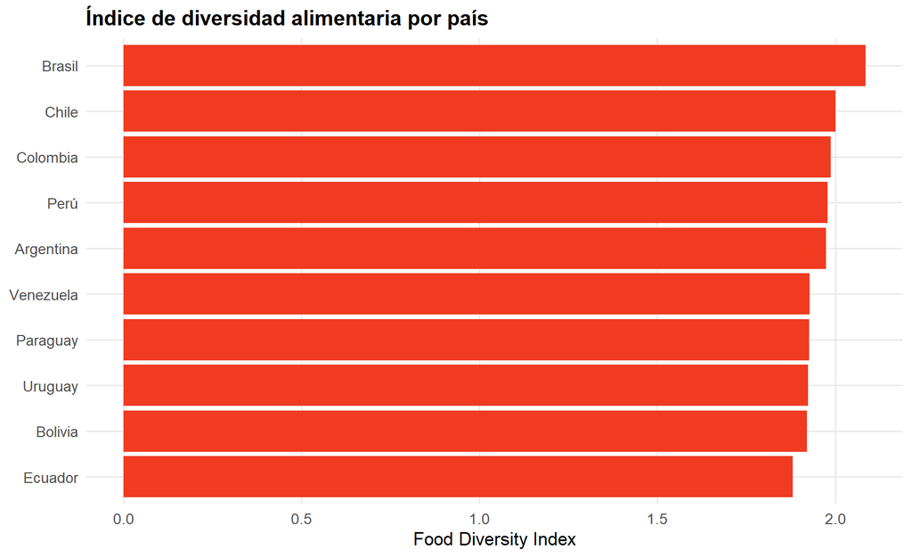

```r
kpis |>
  arrange(desc(food_diversity_index)) |>
  ggplot(aes(x = fct_reorder(pais, food_diversity_index), y = food_diversity_index)) +
  geom_col(fill = "#f03b20") +
  coord_flip() +
  labs(title = "Índice de diversidad alimentaria por país",
       x = NULL, y = "Food Diversity Index")
```

## 6.2 Evolución temporal de la diversidad (panel 2010-2023)

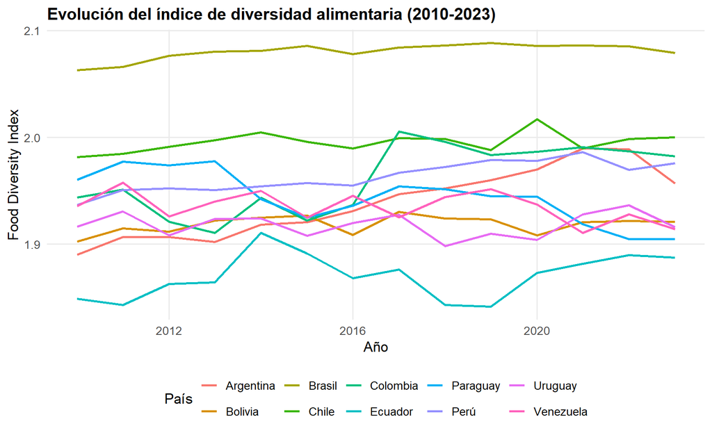

```r
panel |>
  ggplot(aes(x = ano, y = food_diversity_index, color = pais)) +
  geom_line(linewidth = 0.9) +
  labs(title = "Evolución del índice de diversidad alimentaria (2010-2023)",
       x = "Año", y = "Food Diversity Index", color = "País")
```

## 6.3 Composición de la oferta por grupo de alimentos

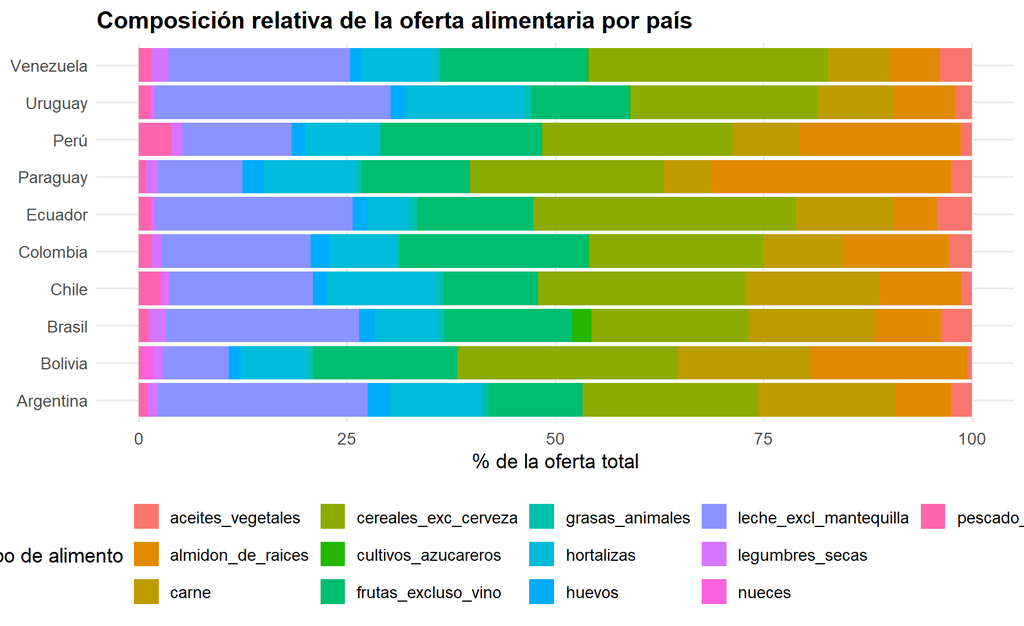

```r
grupos <- c("aceites_vegetales","almidon_de_raices","carne","cereales_exc_cerveza",
            "cultivos_azucareros","frutas_excluso_vino","grasas_animales","hortalizas",
            "huevos","leche_excl_mantequilla","legumbres_secas","nueces",
            "pescado_y_frutos_de_mar")

kpis |>
  select(pais, all_of(grupos)) |>
  pivot_longer(-pais, names_to = "grupo", values_to = "valor") |>
  group_by(pais) |>
  mutate(pct = valor / sum(valor) * 100) |>
  ggplot(aes(x = pais, y = pct, fill = grupo)) +
  geom_col() +
  coord_flip() +
  labs(title = "Composición relativa de la oferta alimentaria por país",
       x = NULL, y = "% de la oferta total", fill = "Grupo de alimento") +
  theme(legend.position = "bottom")
```

# 7 Correlación entre variables

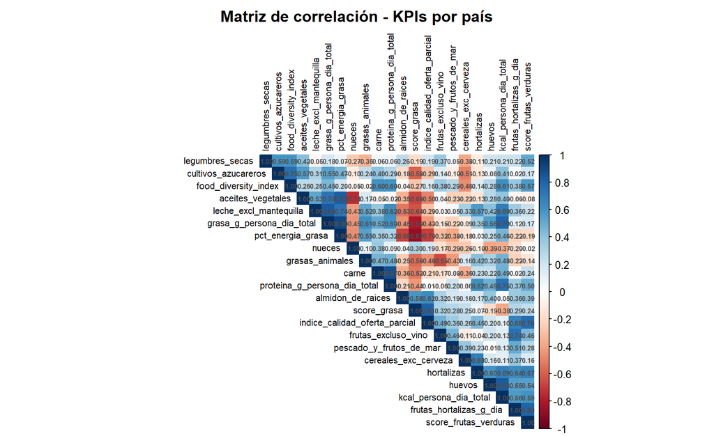

```r
kpis_num <- kpis |> select(where(is.numeric))
mat_cor <- cor(kpis_num, use = "pairwise.complete.obs")

corrplot(mat_cor, method = "color", type = "upper", order = "hclust",
         tl.col = "black", tl.cex = 0.7, addCoef.col = "grey30",
         number.cex = 0.5,
         title = "Matriz de correlación - KPIs por país", mar = c(0,0,2,0))
```

# 8 Reducción de dimensionalidad (PCA)

El dataset `paises_pca_clusters` ya trae calculados `pc1` y `pc2`. Aquí se recalcula el PCA sobre las variables estandarizadas para **verificar e interpretar** los componentes (varianza explicada, cargas de las variables).

```r
pca_vars <- kpis |> select(where(is.numeric)) |> select(-food_diversity_index)
pca_scaled <- scale(pca_vars)
pca_res <- prcomp(pca_scaled, center = FALSE, scale. = FALSE)

summary(pca_res)
```

```
## Importance of components:
##                           PC1    PC2    PC3    PC4     PC5     PC6     PC7
## Standard deviation     2.6398 2.3020 1.7053 1.5116 1.18134 0.84367 0.81698
## Proportion of Variance 0.3318 0.2523 0.1385 0.1088 0.06646 0.03389 0.03178
## Cumulative Proportion  0.3318 0.5842 0.7227 0.8315 0.89792 0.93181 0.96359
##                            PC8     PC9  PC10
## Standard deviation     0.69395 0.53194 7e-16
## Proportion of Variance 0.02293 0.01347 0e+00
## Cumulative Proportion  0.98653 1.00000 1e+00
```

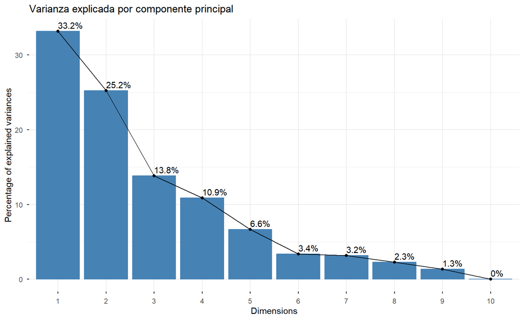

```r
fviz_eig(pca_res, addlabels = TRUE,
         main = "Varianza explicada por componente principal")
```

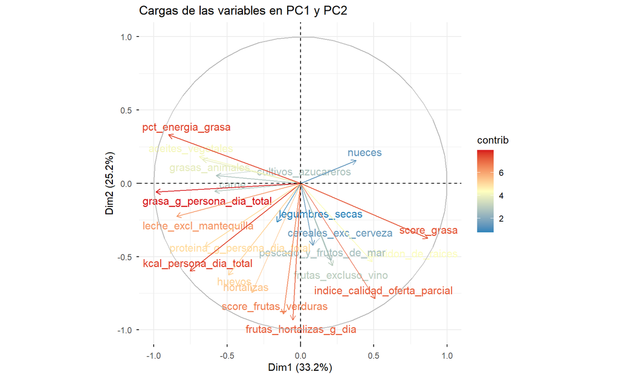

```r
fviz_pca_var(pca_res, col.var = "contrib",
             gradient.cols = c("#2b83ba","#ffffbf","#d7191c"),
             repel = TRUE,
             title = "Cargas de las variables en PC1 y PC2")
```

## 8.1 Biplot con los clústeres ya asignados

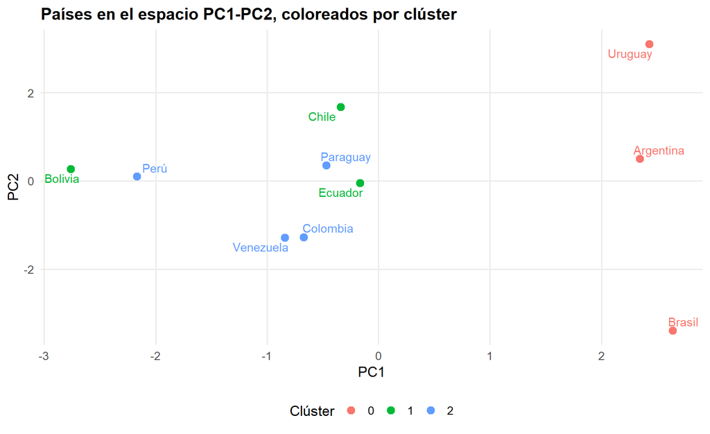

```r
pca_cl |>
  ggplot(aes(x = pc1, y = pc2, color = factor(cluster_kmeans), label = pais)) +
  geom_point(size = 3) +
  ggrepel::geom_text_repel(show.legend = FALSE) +
  labs(title = "Países en el espacio PC1-PC2, coloreados por clúster",
       x = "PC1", y = "PC2", color = "Clúster")
```

# 9 Segmentación (clustering)

## 9.1 Perfil de cada clúster

```r
pca_cl |>
  group_by(cluster_kmeans) |>
  summarise(n_paises = n(),
            paises = paste(pais, collapse = ", "),
            diversidad_media = mean(food_diversity_index),
            kcal_media = mean(kcal_persona_dia_total),
            calidad_media = mean(indice_calidad_oferta_parcial)) |>
  datatable(caption = "Perfil promedio por clúster")
```

|  | cluster_kmeans | n_paises | paises | diversidad_media | kcal_media | calidad_media |
| --- | --- | --- | --- | --- | --- | --- |
| 1 | 0 | 3 | Argentina, Brasil, Uruguay | 1.994334341469612 | 3337.192666666667 | 86.33333333333333 |
| 2 | 1 | 3 | Bolivia, Chile, Ecuador | 1.933950459136641 | 2680.080666666667 | 86.6 |
| 3 | 2 | 4 | Colombia, Paraguay, Perú, Venezuela | 1.95472917325309 | 2892.941 | 98.325 |

## 9.2 Validación con el estadístico de silueta (silhouette)

```
##   cluster size ave.sil.width
## 0       0    3          0.22
## 1       1    3          0.00
## 2       2    4          0.21
```

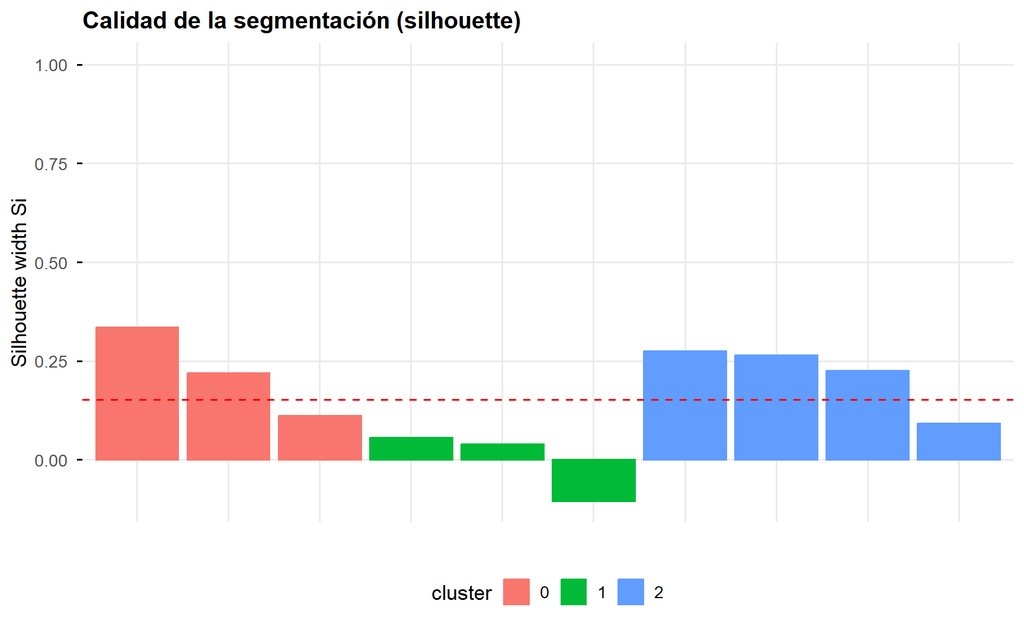

```r
d <- dist(pca_scaled)
sil <- silhouette(pca_cl$cluster_kmeans, d)
fviz_silhouette(sil) +
  labs(title = "Calidad de la segmentación (silhouette)")
```

# 10 Análisis de panel: comercio exterior y autosuficiencia (2010-2023)

```r
panel |>
  group_by(pais) |>
  summarise(autosuficiencia_media = mean(ratio_autosuficiencia),
            dependencia_media = mean(ratio_dependencia_importaciones),
            orientacion_export_media = mean(ratio_orientacion_exportadora)) |>
  arrange(desc(autosuficiencia_media)) |>
  datatable(caption = "Ratios comerciales promedio 2010-2023 por país") |>
  formatRound(columns = 2:4, digits = 2)
```

|  | pais | autosuficiencia_media | dependencia_media | orientacion_export_media |
| --- | --- | --- | --- | --- |
| 1 | Argentina | 1.671767611794893 | 0.02287318101384668 | 0.4033953842904223 |
| 2 | Uruguay | 1.412957819818229 | 0.3161740711628042 | 0.531284692825407 |
| 3 | Paraguay | 1.328632984665395 | 0.03652355802375729 | 0.2782507611957755 |
| 4 | Ecuador | 1.306336054433614 | 0.1141540804555963 | 0.3211598752884279 |
| 5 | Chile | 1.066426611142906 | 0.3170772372309392 | 0.3605243513387264 |
| 6 | Brasil | 1.033187615615064 | 0.01966832522966446 | 0.05144872956278253 |
| 7 | Bolivia | 1.001323758640085 | 0.04886287474881702 | 0.04813072773556425 |
| 8 | Perú | 0.9979506737633882 | 0.1805098010575775 | 0.1831215912507043 |
| 9 | Colombia | 0.9053048506159915 | 0.1351864165599677 | 0.0434894367382997 |
| 10 | Venezuela | 0.756897962914077 | 0.2447395433468471 | 0.002426955111422657 |

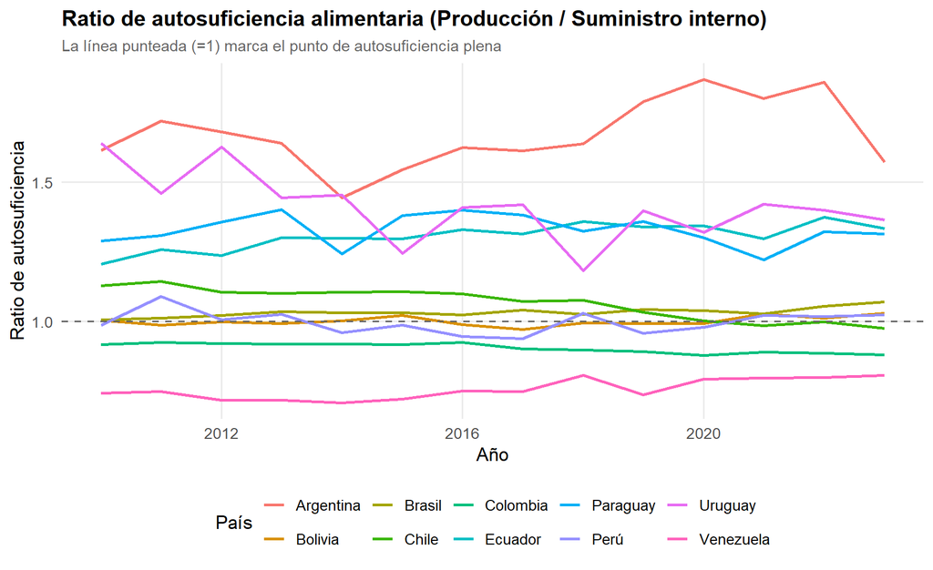

```r
panel |>
  ggplot(aes(x = ano, y = ratio_autosuficiencia, color = pais)) +
  geom_line(linewidth = 0.9) +
  geom_hline(yintercept = 1, linetype = "dashed", color = "grey40") +
  labs(title = "Ratio de autosuficiencia alimentaria (Producción / Suministro interno)",
       subtitle = "La línea punteada (=1) marca el punto de autosuficiencia plena",
       x = "Año", y = "Ratio de autosuficiencia", color = "País")
```

# 11 Pregunta de investigación obligatoria

**¿Existe una relación entre la diversidad de productos disponibles para consumo y la estructura de energía, proteína y otros componentes de la dieta nacional?**

## 11.1 Diversidad alimentaria y calidad de la oferta

```r
kpis |>
  select(pais, food_diversity_index, indice_calidad_oferta_parcial) |>
  arrange(desc(food_diversity_index)) |>
  datatable(caption = "Diversidad vs. calidad de la oferta por país")
```

|  | pais | food_diversity_index | indice_calidad_oferta_parcial |
| --- | --- | --- | --- |
| 1 | Brasil | 2.085021907809123 | 82.2 |
| 2 | Chile | 2.000566992617852 | 98.8 |
| 3 | Colombia | 1.986861595619272 | 100 |
| 4 | Perú | 1.97812928352058 | 100 |
| 5 | Argentina | 1.974522360004487 | 84 |
| 6 | Venezuela | 1.928087348428565 | 93.3 |
| 7 | Paraguay | 1.925838465443942 | 100 |
| 8 | Uruguay | 1.923458756595225 | 92.8 |
| 9 | Bolivia | 1.920967089248648 | 94.6 |
| 10 | Ecuador | 1.880317295543424 | 66.4 |

```r
cor.test(kpis$food_diversity_index, kpis$indice_calidad_oferta_parcial)
```

```
##
##  Pearson's product-moment correlation
##
## data:  kpis$food_diversity_index and kpis$indice_calidad_oferta_parcial
## t = 0.45429, df = 8, p-value = 0.6617
## alternative hypothesis: true correlation is not equal to 0
## 95 percent confidence interval:
##  -0.5232921  0.7166536
## sample estimates:
##       cor
## 0.1585844
```

Brasil (2.09) y Chile (2.00) tienen la mayor diversidad alimentaria del grupo, mientras que Ecuador (1.88) y Bolivia (1.92) tienen la menor. Sin embargo, **diversidad y calidad de la oferta no coinciden**: la correlación entre ambas es débil (r ≈ 0.16). Colombia, Perú y Paraguay alcanzan el puntaje máximo de calidad (100) con niveles de diversidad solo intermedios, mientras que Brasil -el más diverso- tiene una calidad de oferta relativamente baja (82.2) y Ecuador combina la diversidad más baja con la peor calidad (66.4). Esto sugiere que son **dimensiones distintas de la dieta**: una mide cuántos grupos de alimentos distintos componen la oferta, la otra qué tan “saludable” es esa combinación (balance de grasas, frutas/verduras) — un país puede ofrecer pocos grupos de alimentos pero bien balanceados, o muchos grupos con un perfil nutricional desbalanceado.

## 11.2 Perfil productivo/comercial de los clústeres

```r
# Se usa Cluster_KMeans (de paises_pca_clusters) como partición de referencia,
# uniéndolo al panel por país para obtener el perfil comercial promedio.
mapa_cluster <- pca_cl |> select(pais, cluster_kmeans)

panel |>
  left_join(mapa_cluster, by = "pais") |>
  group_by(cluster_kmeans) |>
  summarise(paises = paste(sort(unique(pais)), collapse = ", "),
            produccion_media = mean(produccion_total),
            exportaciones_media = mean(exportaciones_total),
            ratio_autosuficiencia = mean(ratio_autosuficiencia),
            ratio_orientacion_exportadora = mean(ratio_orientacion_exportadora)) |>
  datatable(caption = "Perfil comercial promedio por clúster (usando Cluster_KMeans)")
```

|  | cluster_kmeans | paises | produccion_media | exportaciones_media | ratio_autosuficiencia | ratio_orientacion_exportadora |
| --- | --- | --- | --- | --- | --- | --- |
| 1 | 0 | Argentina, Brasil, Uruguay | 381806.6666666667 | 36073.35714285714 | 1.372637682409395 | 0.3287096022262039 |
| 2 | 1 | Bolivia, Chile, Ecuador | 21686.42857142857 | 5728.404761904761 | 1.124695474738868 | 0.2432716514542395 |
| 3 | 2 | Colombia, Paraguay, Perú, Venezuela | 36603.48214285714 | 3962.982142857143 | 0.9971966179897129 | 0.1268221860740505 |

## 11.3 Correlaciones más fuertes y redundancia para el PCA

Las variables más correlacionadas en el dataset de KPIs son:

| Variables | r |
| --- | --- |
| `Grasa_g_persona_dia_total` — `Pct_Energia_Grasa` | 0.90 |
| `Pct_Energia_Grasa` — `Score_Grasa` | -0.87 |
| `Carne` — `Proteina_g_persona_dia_total` | 0.87 |
| `Leche - Excl Mantequilla` — `Grasa_g_persona_dia_total` | 0.84 |
| `Score_FrutasVerduras` — `Indice_Calidad_Oferta_parcial` | 0.76 |

## 11.4 Evolución de la dependencia de importaciones (2010-2023)

```r
panel |>
  group_by(pais) |>
  summarise(dependencia_2010_2013 = mean(ratio_dependencia_importaciones[ano %in% 2010:2013]),
            dependencia_2020_2023 = mean(ratio_dependencia_importaciones[ano %in% 2020:2023]),
            cambio_pp = (dependencia_2020_2023 - dependencia_2010_2013) * 100) |>
  arrange(desc(cambio_pp)) |>
  datatable(caption = "Cambio en la dependencia de importaciones: inicio vs. final del período (puntos porcentuales)")
```

|  | pais | dependencia_2010_2013 | dependencia_2020_2023 | cambio_pp |
| --- | --- | --- | --- | --- |
| 1 | Chile | 0.2474259437817416 | 0.3993048567196844 | 15.18789129379428 |
| 2 | Uruguay | 0.2722275265456999 | 0.3498696132414282 | 7.764208669572836 |
| 3 | Colombia | 0.1104726134511854 | 0.1561372715026796 | 4.566465805149411 |
| 4 | Perú | 0.1534379776562138 | 0.1948499721624439 | 4.141199450623007 |
| 5 | Ecuador | 0.09864767872478765 | 0.137858425397609 | 3.92107466728213 |
| 6 | Paraguay | 0.03434309418896545 | 0.04560763043661992 | 1.126453624765448 |
| 7 | Brasil | 0.01999644979658995 | 0.01971508370328843 | -0.02813660933015244 |
| 8 | Argentina | 0.02650506392793723 | 0.02044635713154918 | -0.6058706796388049 |
| 9 | Bolivia | 0.04719537359905615 | 0.03972498480582022 | -0.7470388793235929 |
| 10 | Venezuela | 0.2731980625445631 | 0.2098874229627571 | -6.331063958180599 |